# Computational Statistics 5.1: Hypothesis testing

## Hypothesis testing

### Overview

This lesson introduces the basic concepts of a hypothesis test.

### Objectives

After completing this module, students should be able to:

1. Explain the difference between the Null and Research hypothesis.
2. Explain the importance of “rejecting the null”
3. Explain one-tailed vs two-tailed tests and p-values.

### Readings

Lander, Chapter 18.3 Schumacker, Ch. 10

## Randomness and Hypotheses

**Randomness** is a measure of our inability to predict the outcome of an experiment. The *more random* an event is, the less likely we are to correctly predict the outcome. The more we know about the factors that are associated with a certain outcome, the *less random* the event becomes. e.g. if we want to know if it’s going to rain in the next 15 minutes, a good *estimation* of the likelihood of raining can be obtained by looking up and check if the sky is clear or cloudy. We can formalize this exercise by using the concept of conditional probability from the previous learning module:

$$\begin{eqnarray*}
p_{\text{clear}} = & P(y = \text{rain} \;|\; x = \text{clear} ) & =\text{Probability of rain given that the sky is clear} \\
p_{\text{cloudy}} = & \;\; P(y = \text{rain} \;|\; x = \text{cloudy} ) & = \text{Probability of rain given that the sky is clear}
\end{eqnarray*}$$

From simple observation we can *guess* that $p_{\text{cloudy}} > p_{\text{clear}}$, it is more likely to observe rain if the sky is cloudy than clear. This guess is what we call a **hypothesis**. Hypothesis is a synonym of *to suppose* or *to assume*. We learn that $p_{\text{cloudy}} > p_{\text{clear}}$ from the informal observation of past experiences. Moreover, we also know that we are not always right; the fact that $p_{\text{cloudy}} > p_{\text{clear}}$ **does not implies that** $p_{\text{cloudy}} = 1$ and $p_{\text{clear}} = 0$, i.e. is not the case that it will always rain when is cloudy and it will never rain when is sunny.

In this module we are going to learn how we can *test* the assumptions we make about random processes. In other words, we’ll learn how we can use **statistics** and `R` to systematically decide if the assumptions we make about the data can be attributed to random chance.

## Population mean, sample average and hypotheses

Many assumptions about the world have a binary response (yes/no), for example:

- The mean hourly earnings of recent U.S. college graduates equal $20 per hour.
- The mean earnings is not the same for male and female college graduates.
- The proportion of defective products decrease after a new manufacturing process was introduced.
- A ski resort decreased its average response time to accidents.
- A new facial recognition algorithm is faster than the competition.
- Drug $x$ reduce the probability of observing $y$ side-effect in relation to drug $z$.

All the previous hypothesis can be rephrased in terms of population mean. Recall that the **population** of a distribution is the actual or real distribution of a random experiment. The **population mean** is the average of the population, we often use the term the *real* or *actual* mean to refer to the population mean.

Because the population of a random experiment is not observable - we never with total certainty the actual distribution that is generating the data, unless we are using a computer simulation - we need to use an **estimation**. An **estimator** is a function of a sample data to be drawn randomly from the population. The **sample mean** or sample average is an estimation of the population mean. Note that the sample mean is a random variable because it depends on the sample data, which is a random draw of the population.

**Example:** Imagine that we want verify the hypothesis *“The mean hourly earnings of recent U.S. college graduates equal $20 per hour”*. It is impossible for us to observe the population of hourly earnings of U.S. college graduates, but we can survey a number $n$ of individuals and use the sample average as an estimator of the population mean. Let’s simulate this in `R`, in this instance we are going to assume that the actual population mean is indeed $20.

```r
set.seed(1) # To get same data always
N <- 1000000 #population size
mu <- 20 #population mean
sigma <- 10 # population standard deviation
population <- rnorm(N, mu, sigma) #population

# Population mean
mean(population)
```

```
## [1] 20.00047
```

Now let’s take 3 samples of 10 observations and compare them:

```r
set.seed(1) # To get same data always
n <- 10 #sample size
sample1 <- sample(population, size = n )
sample2 <- sample(population, size = n )
sample3 <- sample(population, size = n )

mu1 <- mean(sample1)
mu2 <- mean(sample2)
mu3 <- mean(sample3)

c(mu1,mu2,mu3)
```

```
## [1] 19.94367 19.02149 22.09363
```

We can verify that the different samples are (1) close to the population mean but, in generally, not exactly equal, and, (2) each sample mean is different from each other.

Unfortunately, in most practical applications we’ll have only one sample to assess the validity of a proposed hypothesis. For example, if we want to know if the population mean is equal to $\$20$, formally, $\mu_{x} = 20$. Using the first sample we compute a sample average, which is $\;\approx\;$ `19.94`, or a 0.06 difference from the proposed hypothesis value of 20. Is this difference enough to **reject** the assumption that the population mean is equal to 20? there will always be some difference due to the fact that we only have a random sample, how tolerant are we as researcher to those discrepancies? The process of testing a hypothesis involve answering the previous questions.

### Null and Alternative Hypothesis

Before we test a hypothesis, we need to first learn how to properly write it in a way that we can use statistics to test it. This is very simple, you just need to follow this simple steps:

1. Formalize the hypothesis statement in terms of the population mean, generally using non-ambiguous terminology and/or a clear mathematical notation.
2. Consider what would be true if the hypothesis statement is false, then formalize this idea just like you did with case (1).

For example, say we want to formalize the example from the previous slide: *“The mean hourly earnings of recent U.S. college graduates equal $20 per hour"*. First, let's write the statement as a function of the population mean ($_{x}$).

1. $\mu_{x} = 20$.

Now, we just need to consider what would be true if (1) is false. We have different candidates, it could be that $\mu_{x} > 20$ or $\mu_{x} < 20$, which can be succinctly expressed as:

### Hypothesis Testing Notation

We call **null hypothesis** ($H_{0}$) to the starting point of a statistical hypothesis test and **alternative hypothesis** ($H_{A}$ or ($H_{1}$)) to the what is true when the null hypothesis is false. This terms are part of the convention of methodology hypothesis testing, we *always* make them explicit and clear so that others researchers when verifying our work can clearly understand what are the starting assumptions and how we express them in the test - this is critical in some applications -.

Then, let’s write the previous example using the notation of hypothesis testing.

$$\begin{eqnarray*}
H_{0}: & \;\;\; \mu_{x} = & 20 \\
H_{A}: & \;\;\; \mu_{x} \neq & 20
\end{eqnarray*}$$

or

$$\begin{eqnarray*}
\text{Null Hypothesis}: & \;\;\; \mu_{x} = & 20 \\
\text{Alternative Hypothesis}: & \;\;\;\mu_{x} \neq & 20
\end{eqnarray*}$$

Let’s practice writing hypothesis for some of the other research questions from the first slide of this section:

- The mean earnings is not the same for male and female college graduates.

$$\begin{eqnarray*}
H_{0}: & \;\;\; \mu_{\text{male}} \neq & \mu_{\text{female}} \\
H_{A}: & \;\;\; \mu_{\text{male}} = & \mu_{\text{female}}
\end{eqnarray*}$$

- A new facial recognition algorithm is faster than the competition. ($\mu_{x} =$ average time)

$$\begin{eqnarray*}
H_{0}: & \;\;\; \mu_{x} < & \mu_{\text{competition}} \\
H_{A}: & \;\;\; \mu_{x} \geq & \mu_{\text{competition}}
\end{eqnarray*}$$

### Testing

Let’s imagine that we have a sample with the following characteristics

1. Sample average, $\bar{x} = 2$,
2. Sample standard deviation, $s = 5$, and,
3. Sample size $n = 100$.

We want to test the hypothesis that the population average is equal to zero $\mu = 0$, under the assumption that the population distribution is normal. First, let’s formalize this statement:

$$\begin{eqnarray*}
\text{Null Hypothesis}: & \;\;\; \mu = & 0 \\
\text{Alternative Hypothesis}: & \;\;\;\mu \neq & 0
\end{eqnarray*}$$

Now, let’s think how using our knowledge of the normal distribution we can use the sample to test the hypothesis. In any given sample, the sample average $\bar{x}$ will rarely be exactly equal to the hypothesized value ($\mu = 0$). Differences between $\bar{x}$ and $\mu$ can arise because the true mean is in fact not equal to the hypothesis value (which implies that the null hypothesis is false) or because the true mean is equal to $\mu$ but $\bar{x}$ differs from $\mu$ due to random sampling (which does not implies that the null hypothesis is false). It is impossible to distinguish between these two possibilities with total certainty.

Even if a sample cannot provide conclusive evidence about the null hypothesis, it is possible to do a probabilistic calculation that permits testing the null hypothesis in a way that accounts for sample uncertainty.

### Standard error and Confidence intervals

The probabilistic calculation that allow us to test hypothesis lies in the concept of standard errors and confidence intervals.

Remember, a standard error works in two ways:

1. The standard error determines the dispersion of the distribution of sample average values around the population mean.
2. The standard error also allows to make claims about where $\mu$ is relative to $\bar{x}$.

In the previous example, **what is standard error of the sample?**:

$$S.E. = \dfrac{s}{\sqrt{n}} = \dfrac{5}{\sqrt{100}} = \dfrac{5}{10} = \dfrac{1}{2}$$

The value of $S.E. =\dfrac{1}{2}$ means that the if we collect different samples and compute the sample mean, the average or standard difference from the mean will be equal to $0.5$. Note how important this concept is, it is telling us what is the average difference between the observed sample average and the real value of the population mean. Maybe if the difference between the hypothesis value and the sample average is less than the standard error we can conclude that this difference is the result of random sample? This would imply that we cannot reject the idea that the hypothesis value is different than the population mean. The concept of hypothesis testing is based on this idea.

### Rejecting the Null Hypothesis

Imagine that the null hypothesis is true, i.e. $\mu = 0$. Then, using to the normal distribution, we can build the following confidence intervals:

- 90% confidence interval [$\bar{\mu} \pm 1.64 \times S.E.$] or $\{0 \pm 1.64 \times 0.5\} = \{-0.82, 0.82\}$
- 95% confidence interval [$\bar{\mu} \pm 1.96 \times SE$] or $\{0 \pm 1.96 \times 0.5\} = \{-0.98, 0.98\}$
- 99% confidence interval [$\bar{\mu} \pm 2.58 \times SE$] or $\{0 \pm 2.58 \times 0.5\} = \{-1.29, 1.29\}$

In other words, if the null is true there is a:

- 90% chance that the the sample average is in the confidence interval $\{-0.82, 0.82\}$
- 95% chance that the the sample average is in the confidence interval $\{-0.98, 0.98\}$
- 99% chance that the the sample average is in the confidence interval $\{-1.29, 1.29\}$

Now, with a sample average $\bar{x} = 2$ we can conclude that: The null hypothesis - the assumption that the population mean is equal to zero - is not consistent with the observed sample average of $2$. This is due to the fact that, if the real value of the population mean is zero, there is a 90% chance that sample average is between $\{-0.82, 0.82\}$, a 95% that is between $\{-0.98, 0.98\}$ and a 99% chance that is between $\{-1.29, 1.29\}$. But the sample average is not within any of the presented confidence intervals. Therefore, we cannot argue convincingly, that the reason why the sample average is different than the hypothesized value is due to random chance.

In summary, *if the sample average **is not** in the confidence interval of the null hypothesis, we reject the null hypothesis*. Note that rejecting the null does not imply accepting the alternative, **we never prove a hypothesis**, we can simply find enough evidence to reject it.

### “In favor of…”

**Now that we have rejected the null hypothesis, can we say that Hypothesis A is true?**

No.

- We have rejected the null “in favor of” the alternative hypothesis. We have not necessarily proven the alternative and we cannot accept it.
- This is the so-called *frequentist* approach, we never really prove anything, we can just disprove our prior knowledge or theories.
- We “provisionally” consider a hypothesis as probably true until we can reject it. Knowledge or scientific consensus is built when there are enough instances were a hypothesis cannot be rejected.

## Type 1 and Type 2 Errors

A statistical hypothesis test can make two types of mistakes:

**Type 1 Error = False Positive**: Is when the researcher rejects the Null Hypothesis while in fact it shouldn’t have. Using a 95% confidence interval to test a hypothesis, on average, if we collect 100 different samples, 5 of them will produce false positives or type 1 errors. The **significance level** is the probability of committing a type 1 error, therefore, a hypothesis test based on a 95% confidence interval has a 5% significance level.

**Type 2 Error = False Negative**: Is when the researcher fails to reject the Null Hypothesis while it should have. One minus the probability of a type 2 error is called the **power of the test**. Generally we cannot determine the power of the test, because it requires prior knowledge of the actual population.

|  | Null hypothesis is true | Null hypothesis is false |
| --- | --- | --- |
| **Reject the null** | False positive (Type 1 error) | OK |
| **Fail to reject the null** | OK | False negative (Type 2 error) |

The typical **95% CI’s** was designed to avoid Type 1 errors, even at the cost of greater Type 2 error. We rather fail to reject the null than mistakenly reject the null: we need strong evidence to reject prior knowledge!

## P-value and rejection region

Based on a confidence interval, we can determine the two regions:

1. **Rejection Region**: a set of values for which we reject the null hypothesis.
2. **Acceptance Region**: a set of values for which we cannot reject the null hypothesis.

In the following graph, we are representing the rejection region (in dark blue) and the acceptance region (in light blue) of the hypothesis test that $\mu = 0$, with $S.E. = 1$. Note that the standard error if $S.E = 1$:

- 95% confidence interval [$\bar{\mu} \pm 1.96 \times SE$] or $\{0 \pm 1.96 \times 1\} = \{-1.96, 1.96\}$

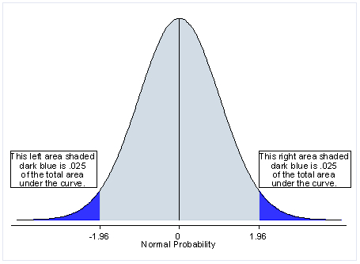

Then, $\{-1.96, 1.96\}$ is the acceptance region, and the values outside of $\{-1.96, 1.96\}$ is the rejection region. The probability or the mass of the rejection region is called the p-value. We can compute the p-value in `R` using the `pnorm` function:

```r
# Note that we have to multiply
# the pnorm() calculation by 2
# because we have to consider
# both tails of the distribution.

pnorm(1.96, 0, 1, lower.tail=F)*2
```

```
[1] 0.04999579
```

```r
#Or:
(1-pnorm(1.96,0,1))*2
```

```
[1] 0.04999579
```

Which is approximately 5%. We can compare the p-value and the significance level of a hypothesis test to determine if *the probability of rejecting the null is greater than the probability of a type 1 error*, which is equivalent to rejecting the null using the confidence interval.

### One-Tailed vs Two-Tailed Tests

- A **one-tailed test**: Is a hypothesis test were the hypothesis is directional, i.e. the researcher is only interested in testing $\mu > 0$ (or only interested in $\mu < 0$). e.g. Are computer science majors more likely to be unemployed 1 year after graduation than other graduates? is the monthly average temperature lower in February?, etc.
- A **two-tailed test**: Is a hypothesis test were the hypothesis is not-directional. i.e. the researcher is only interested in $\mu = 0$ or $\mu \neq 0$. e.g. Are computer science majors equally likely to be unemployed 1 year after graduation than other graduates? is the monthly average temperature different in February?, etc.

The type of test (one-tailed or two-tailed) that is under consideration is important because the calculation of the confidence interval and rejection regions will be different.

### One-tailed rejection region

By definition, the rejection region of a one-tailed test should include only region in which the null is rejected. If the significance level of the test is 5% then, the mass of the rejection region should be equal to 5%.

- If the hypothesis is of the form $\mu > \mu_0$ - where $\mu_0$ is the hypothesized value -. Then, the rejection region is:

$$\mu_0 - \text{z-val}(\alpha) \times S.E. = \mu_0 - 1.64 \times S.E. = (-\infty, \mu_0 - 1.64 \times S.E.)$$

This is the case because if the null is true, then observing a sample average greater than $\mu_0$ is supporting of the null that the population mean is greater than the hypothesized value. Only if the sample mean is sufficiently lower than the hypothesized value we can reject the null.

- If the hypothesis is of the form $\mu < \mu_0$. Then, the rejection region is:

$$\mu_0 + \mu_0 _ \text{z-val}(\alpha) \times S.E. = \mu_0 + 1.64 \times S.E. = (\mu_0 + 1.64 \times S.E., \infty)$$

This is the case because if the null is true, then observing a sample average less than $\mu_0$ is supporting of the null that the population mean is less than the hypothesized value. Only if the sample mean is sufficiently greater than the hypothesized value we can reject the null.

You may be wondering, why I used 1.64 instead of 1.96 for a 95% confidence interval. Well, in the case of a one sided test 1.96 would give a rejection region of only 2.5% (for two tails is 5%, but we are only considering one). The following graph represents the rejection region of the hypothesis $\mu_0 + 1.64 \times S.E$

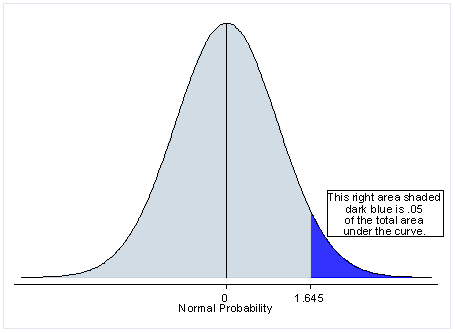

In `R`, is very simply to find the z-value to compute the confidence interval of a one-tailed test given a significance level using the `qnorm` function:

```r
significance <- 0.05
qnorm(1-significance ,0,1)
```

```
[1] 1.644854
```

### Example of one-tailed test

Imagine that we want to test that $\mu > 1$ and we observe $\bar{x} = 1.2$, $s = 1$ and $n = 100$.

- Step 1: Formalize hypothesis:

$$\begin{eqnarray*}
\text{Null Hypothesis}: & \;\;\; \mu > & 1 \\
\text{Alternative Hypothesis}: & \;\;\;\mu \leq & 1
\end{eqnarray*}$$

- Step 2: Set significance level ($\alpha = 0.05$)
- Step 3: Compute Standard Error.

```r
s <- 1
n <- 100

se <- s / sqrt(n)
se
```

```
## [1] 0.1
```

- Step 4: Compute rejection confidence interval: Because this is a *greater than* hypothesis,

$$\mu_0 - \text{z-val}(\alpha) \times S.E.$$

```r
mu <- 1
alpha <- 0.05
zval <- qnorm(1-alpha, 1, se)
mu - zval*se
```

```
## [1] 0.8835515
```

Then the rejection region is,
$$(-\infty, 0.88)$$

Because the sample mean is not in the rejection region, we cannot reject the null hypothesis. We need to observe a sample mean of 0.88 or less to reject the null. This value is known as the **critical value** of a hypothesis test.

### Two-tailed rejection region

By definition, the rejection region of a two-tailed test should include the all the region in which the null is rejected, that is the area under both tails. If the significance level of the test is 5% then, the mass of the rejection region should be equal to 5%. Then, the mass of each tail should be equal to $5\%/2 = 2.5\%$.

- If the hypothesis is of the form $\mu \neq \mu_0$ - where $\mu_0$ is the hypothesized value -. Then, the rejection region is:

$$\mu_0 \pm \text{z-val}(\alpha) \times S.E. = \mu_0 \pm 1.96 \times S.E. = (\mu_0 - 1.96 \times S.E., \mu_0 + 1.96 \times S.E.)$$

- If the hypothesis is of the form $\mu = \mu_0$ - where $\mu_0$ is the hypothesized value -. Then, the rejection region is:

$$(-\infty, \mu_0 - \text{z-val}(\alpha) \times S.E.) \cap (\mu_0 + \text{z-val}(\alpha) \times S.E.,\infty) = (-\infty, \mu_0 - 1.96 \times S.E.) \cap ( \mu_0 + 1.96 \times S.E., \infty)$$

See the figure for an illustration of this.

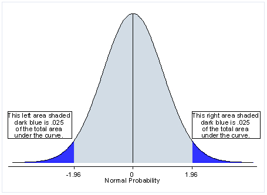

In `R` we can compute the $\text{z-val}(\alpha)$ of each tail:

```r
qnorm(.025,0,1) # Lower tail zval
```

```
[1] -1.959964
```

```r
qnorm(.975,0,1) # Upper tail zval
```

```
[1] 1.959964
```

```r
# Because the normal distribution is symmetric we can do
qnorm(.025,0,1) # Lower tail
```

```
[1] -1.959964
```

```r
-qnorm(.025,0,1) # Upper tail zval
```

```
[1] 1.959964
```

### Example of two-tailed test

Imagine that we want to test that $\mu = 1$ and we observe $\bar{x} = 1.2$, $s = 1$ and $n = 100$.

- Step 1: Formalize hypothesis:

$$\begin{eqnarray*}
\text{Null Hypothesis}: & \;\;\; \mu = & 1 \\
\text{Alternative Hypothesis}: & \;\;\;\mu \neq & 1
\end{eqnarray*}$$

- Step 2: Set significance level ($\alpha = 0.05$)
- Step 3: Compute Standard Error.

```r
s <- 1
n <- 100

se <- s / sqrt(n)
se
```

```
## [1] 0.1
```

- Step 4: Compute rejection confidence interval: Because this is a *equal than* hypothesis,

$$(-\infty, \mu_0 - \text{z-val}(\alpha) \times S.E.) \cap (\mu_0 + \text{z-val}(\alpha) \times S.E.,\infty)$$

```r
mu <- 1
alpha <- 0.05/2 #Two tailed test
zval <- qnorm(1-alpha, 1, se)
c(mu - zval*se, mu + zval*se)
```

```
## [1] 0.8804004 1.1195996
```

Then the rejection region is,
$$(-\infty, 0.88) \cap (1.12, \infty)$$

Because the sample mean is in the rejection region, we reject the null hypothesis. We need to observe a sample mean between 0.88 or 1.12 to fail to reject the null.